# The CircIMPACT package - exploring molecular pathways by linking circular RNA to genes and pathways

Alessia Buratin

Departement of Biology, Department of Molecular Medicine, University of Padova

30-06-2022

## Overview

*circIMPACT* provides a strategy to analyze circular and linear transcriptome rely on data mining and statistical learning techniques. *circIMPACT* package offers a tidy pipeline, starting from the provided circRNA which expression classifies samples with high and low expression of it, a comprensive transcriptome and molecular pathway analysis are performed, including visualisation, normalization, classification, clustering, Differential Expression Analysis and Gene Set Enrichment Analysis. The package accepts data presented as a matrix of raw counts and allows the inclusion of variables that occur with the experimental setting. A series of functions enables data cleaning by filtering rows, data adjustment by identify and removing the unwonted source of variation and to select the best predictors for modeling the responce variable. A learning technique is applied to build a robust classification model, and also an unsupervised analysis is carried out to gain mechanistic insights and detect the molecular pathway associated with the expression levels of the selected circRNA. Finally, a Differential Expression Analysis identyfied deregulated mRNAs and a GSEA is performed for them. *circIMPACT* stands for “circRNA impacted genes and pathways”. circIMPACT package version: 0.1.3

*circIMPACT* provides an R interface to analyze a possible impact of circRNA expression profile in gene expression.

The toolset performs functional enrichment analysis and visualization of gene lists obtained comparing samples with low circRNA expression with those with high expression.

The input for any of the tools consist in count matrices: from the same samples we need the quantification of circular and linear RNAs.

## Installation and loading

```r
devtools::install_github("AFBuratin/circIMPACT", force = TRUE)
```

```r
library(circIMPACT)
library(DESeq2)
library(data.table)
library(plyr)
library(Rtsne)
library(ggplot2)
library(ggrepel)
library(plotly)
library(ComplexHeatmap)
library(circlize)
library(viridis)
library(knitr)
library(kableExtra)
library(formattable)
library(htmltools)
library(sparkline)
library(tidyverse)
library(RColorBrewer)
library(purrr)
library(magrittr)
library(randomForest)
library(DaMiRseq)
library(webshot)
library(ggpubr)
library(tidyr)
library(factoextra)
library(NbClust)
```

### Input data

```r
data("circularData")
data("count.matrix")
data("meta")
data("coldata.df")
## define sample/condition colors
intgroup.dt <- meta[, .(.N), by = .(sample,
                                      condition)][order(sample),
                                                  .(sample), by = condition]
samples.per.condition <- data.frame(intgroup.dt[, .N, by = .(condition)], row.names = "condition")

n.conditions <- nrow(samples.per.condition)
hues <- circIMPACT::gg_color_hue(n.conditions)
for(i in 1:n.conditions){
      n.hues <- samples.per.condition[i, "N"] + 2
      col.hues <- colorRampPalette(colors = c(hues[i],
                                              "white"))(n.hues)[1:(n.hues-2)]

      intgroup.dt[condition == rownames(samples.per.condition)[i], `:=`(color = col.hues,
                                                                        hue = hues[i])]
    }
## create a deseq dataset object
dds.circular <- suppressMessages(DESeqDataSetFromMatrix(countData = ceiling(circularData[, coldata.df$sample[order(coldata.df$condition)]]),
                                   colData = coldata.df[order(coldata.df$condition),],
                                   design = ~ condition))
dds.circular <- suppressMessages(estimateSizeFactors(dds.circular))
sf <- sizeFactors(dds.circular)
```

At first a simply filter of low count is applied to remove background noise.

```r
data.filt <- circularData[rowSums(circularData >= 10) >= 2,]
dds.filt.expr <- suppressMessages(DESeqDataSetFromMatrix(countData = ceiling(data.filt[,coldata.df$sample[order(coldata.df$condition)]]),
                                   colData = coldata.df[order(coldata.df$condition),],
                                   design = ~ condition))
dds.filt.expr <- suppressMessages(estimateSizeFactors(dds.filt.expr))
sf.filt <- sizeFactors(dds.filt.expr)
circNormDeseq <- counts(dds.filt.expr, normalized = T)
```

### CircRNA-markers

```r
circIMPACT <- circIMPACT::marker.selection(dat = circNormDeseq,
                               dds = dds.filt.expr,
                               sf = sf.filt, p.cutoff = 0.05, lfc.cutoff = 1)

circIMPACT_Kmeans <- circIMPACT::marker.selection(dat = circNormDeseq,
                                      dds = dds.filt.expr,
                                      sf = sf.filt, p.cutoff = 0.05, lfc.cutoff = NULL,
                                      method.d = "euclidean", method.c = "ward.D2",
                                      median = FALSE, choose.k = TRUE, index.m = "silhouette")
```

The result `list` will include:

- circ.markers - a data frame with DESeq estimates for each circRNAs.
- circ.targets - a vector of circRNAs defined as possible targets.
- group.df - data.frame with a variable group that indicate the new stratification of samples by circRNAs expression.
- plot - formatted table with info. about circIMPACT expression.

### Density expression of circRNA-IMPACT

```r
circMark <-"11:33286412-33287511"
circIMPACT_Kmeans$group.df[circIMPACT_Kmeans$group.df$circ_id==circMark,]
```

```
#>                  circ_id  sample_id group
#> 721 11:33286412-33287511 SRR5398213    g1
#> 722 11:33286412-33287511 SRR5398214    g1
#> 723 11:33286412-33287511 SRR5398215    g1
#> 724 11:33286412-33287511 SRR5398216    g2
#> 725 11:33286412-33287511 SRR5398217    g1
#> 726 11:33286412-33287511 SRR5398218    g1
```

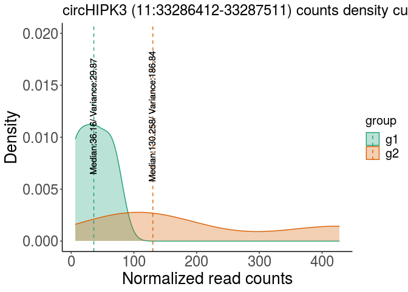

```r
circMark_group.df <- circIMPACT$group.df[circIMPACT$group.df$circ_id==circMark,]
circMark_group.df$counts <- merge(circMark_group.df, reshape2::melt(circNormDeseq[circMark,]), by.x = "sample_id", by.y = "row.names")[,"value"]
mu <- ddply(circMark_group.df, "group", summarise, Mean=mean(counts), Median=median(counts), Variance=sd(counts))

p <- ggplot(circMark_group.df, aes(x=counts, color=group, fill=group)) +
  geom_density(alpha=0.3) +
  ylim(c(0,0.02)) +
  geom_vline(data=mu, aes(xintercept=Median, color=group),
             linetype="dashed") +
  geom_text(data=mu, aes(x=Median[group=="g1"] - 1,
                         label=paste0("Median:", round(Median[group=="g1"], 2), "/ Variance:", round(Variance[group=="g1"], 2)), y=0.012),
            colour="black", angle=90, text=element_text(size=12)) +
  geom_text(data=mu, aes(x=Median[group=="g2"] - 1,
                       label=paste0("Median:", round(Median[group=="g2"], 3), "/ Variance:", round(as.numeric(Variance[group=="g2"]), 2)), y=0.012),
          colour="black", angle=90, text=element_text(size=11)) +  scale_fill_brewer(palette="Dark2") +
  scale_color_brewer(palette="Dark2") +
  labs(title=paste0("circHIPK3 (", circMark, ")", " counts density curve"), x = "Normalized read counts", y = "Density") +
  theme_classic() +
  theme(axis.text.x = element_text(size=18),
        axis.text.y = element_text(size=18),
        axis.title = element_text(size=20),
        legend.text = element_text(size=15),
        legend.title = element_text(size=15),
        plot.title = element_text(size = 18),
        plot.subtitle = element_text(size = 13, color = "darkslategrey"))
p
```

### Clustering analysis using CircRNA-markers

Clustering analysis is performed using the previuos selected circRNA, defined as circRNA-markers. T-SNE algorithm is used to performe dimensionality reduction and k-means and hierarchical clustering methods are compared in order to identify two cluster of samples.

```r
markers.circrnas <- circIMPACT$circ.targetIDS
mat.filt.mark <- circularData[markers.circrnas, ]

dds.filt.mark <- DESeqDataSetFromMatrix(countData = ceiling(mat.filt.mark[,coldata.df$sample]),
                                   colData = coldata.df,
                                   design = ~ 1)
dds.filt.vst <- varianceStabilizingTransformation(dds.filt.mark, fitType = "local", blind = F)
norm.counts.filt <- assay(dds.filt.vst)
```

```r
dt <- norm.counts.filt
```

```r
## Rtsne function may take some minutes to complete...
set.seed(9)
mydist <- dist(t(norm.counts.filt))
## t-SNE representation
# set a perplexity parameter consistent with the number of samples
tsne_data <- Rtsne(mydist, pca = F, perplexity=1, max_iter=5000)

## getting the two dimension matrix
d_tsne_1 = as.data.frame(tsne_data$Y)
rownames(d_tsne_1) <- colnames(norm.counts.filt)
```

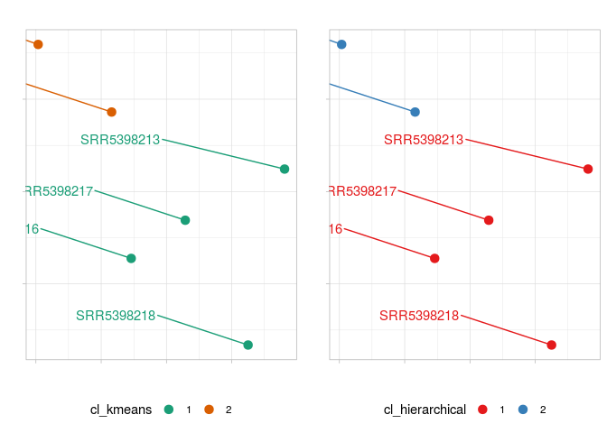

t-SNE dimensionality reduction representation. K-means and hierarchical clustering are compared.

```r
## keeping original data
d_tsne_1_original=d_tsne_1

## Creating k-means clustering model, and assigning the result to the data used to create the tsne
fit_cluster_kmeans=kmeans(scale(d_tsne_1), 2)
d_tsne_1_original$cl_kmeans = factor(fit_cluster_kmeans$cluster)

## Creating hierarchical cluster model, and assigning the result to the data used to create the tsne
fit_cluster_hierarchical=hclust(dist(scale(d_tsne_1)))

## setting 2 clusters as output
d_tsne_1_original$cl_hierarchical = factor(cutree(fit_cluster_hierarchical, k=2))

# Plotting the cluster models onto t-SNE output

plot_cluster=function(data, var_cluster, palette)
{
  ggplot(data, aes_string(x="V1", y="V2", color=var_cluster)) +
  geom_point(size=3) +
  guides(colour=guide_legend(override.aes=list(size=3))) +
  geom_text_repel(aes(label = rownames(data)),
                  hjust = 0.5, vjust = -1) +
  xlab("") + ylab("") +
  ggtitle("") +
  theme_light(base_size=11) +
  theme(axis.text.x=element_blank(),
        axis.text.y=element_blank(),
        legend.direction = "horizontal",
        legend.position = "bottom",
        legend.box = "horizontal") +
    scale_colour_brewer(palette = palette)
}


plot_k=plot_cluster(d_tsne_1_original, "cl_kmeans", "Dark2")
plot_h=plot_cluster(d_tsne_1_original, "cl_hierarchical", "Set1")

## and finally: putting the plots side by side with gridExtra lib...
library(gridExtra)
grid.arrange(plot_k, plot_h,  ncol=2)
```

### CircRNA ranking

After Principal Component Analysis for each circRNAs previously selected a contribution in variance explanation of the two condition comparade will be computed in order to rank circRNA for further analysis. The results can be investigated with visual representation in the PCA plot, by using **fviz_pca_biplot** function in the package *factoextra* or with a table with measure of contribution, obtained by **get_pca_var** function, for each circRNAs.

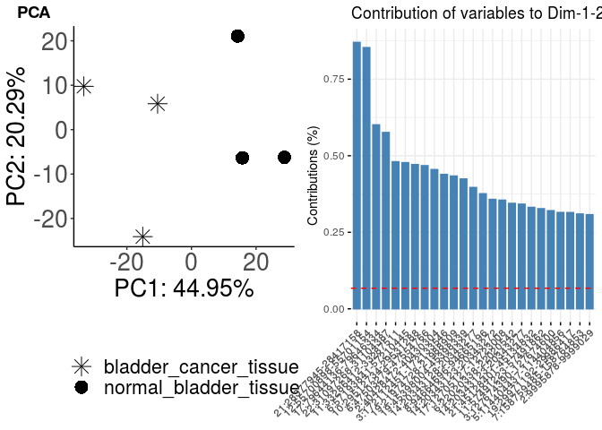

```r
pca <- prcomp(x = t(norm.counts.filt), center = T)
d <- data.frame(pca$x[rownames(coldata.df), c("PC1", "PC2")], coldata.df)
PC1.var <- summary(pca)$importance["Proportion of Variance", 1]
PC2.var <- summary(pca)$importance["Proportion of Variance", 2]
g1 <- ggplot(data = d,
       mapping = aes(x = PC1, y = PC2, shape = condition)) +
    geom_point(size = 5) +
    coord_fixed(ratio = 1) +
    xlab(paste0("PC1: ", percent(PC1.var))) +
    ylab(paste0("PC2: ", percent(PC2.var))) +
    scale_shape_manual("", values = c(8,16)) +
    theme_classic() +
    theme(legend.position = "bottom",
          legend.direction = "vertical",
          plot.title = element_text(hjust = .5),
          text = element_text(size=20),
          axis.text.x = element_text(size=20),
          axis.text.y = element_text(size=20),
          aspect.ratio = 1)


circRNArank = circIMPACT::circ_contrib(matrix_pc = pca, K = 25)


ggpubr::ggarrange(ggarrange(g1, circRNArank$plot,
                            ncol = 2,
                            labels = c("PCA", "")),
                  nrow = 1)
```

**circ_contrib** function select the top **K** circRNAs ranked by their contirubution in variance explanation for PC1 and PC2.

## PCA biplot

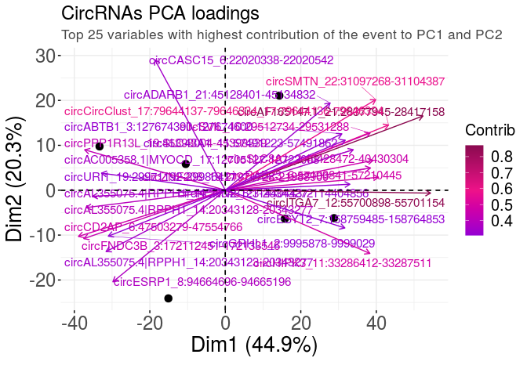

```r
library(factoextra)
res = fviz_contrib(pca, choice ="var", axes = 1, top = 25)
top25 = res$data$name[order(res$data$contrib, decreasing=T)][1:25]
circAnnotation = read.csv("/media/Data/Li/circRNA_expression_per_sample.csv", header = T)

circAnnotation$circCHR =  sub(":.*", "", circAnnotation$circ_id)
circAnnotation$circstart = gsub(".*:(.*)\\-.*", "\\1", circAnnotation$circ_id)
circAnnotation$circend = sub(".*-", "\\1", circAnnotation$circ_id)
circAnnotation$circ_id <- paste0(circAnnotation$circCHR, ":", as.numeric(circAnnotation$circstart)-1, "-", circAnnotation$circend)

rownames(pca$rotation) = paste0("circ", circAnnotation$gene_names[match( rownames(norm.counts.filt), circAnnotation$circ_id)], "_", rownames(norm.counts.filt))

p = fviz_pca_biplot(pca, #select.ind = list(contrib = 5),
               select.var = list(contrib = 25),
               ggtheme = theme_minimal(),
               title = "CircRNAs PCA loadings",
               #habillage=coldata.df$condition,
               # Individuals
                geom.ind = "point",
                #fill.ind = coldata.df$condition,
               col.ind = "black",
              #pointshape = coldata.df$condition,
               pointsize = 3,
                palette = "jco",
                addEllipses = FALSE,
               repel = TRUE,
                # Variables
               # alpha.var ="contrib",
               col.var = "contrib",
                # gradient.cols = c("#C51B7D", "#E9A3C9", "#A1D76A", "#4D9221"),
                gradient.cols = c("darkviolet", "deeppink2", "deeppink4"),
                legend.title = list(shape = "Condition", color = "Contrib")) +
                                    #alpha = "Contrib")) +
  labs(subtitle = "Top 25 variables with highest contribution of the event to PC1 and PC2",
       caption = "") +
  theme(axis.text.x = element_text(size=18),
        axis.text.y = element_text(size=18),
        axis.title = element_text(size=20),
        legend.text = element_text(size=15),
        legend.title = element_text(size=15),
        plot.title = element_text(size = 18),
        plot.subtitle = element_text(size = 13, color = "gray28"))
p
```

### Heatmap using CircRNA-IMPACT

```r
set.seed(201)
dds.filt.mark <- estimateSizeFactors(dds.filt.mark)
circNormDeseq <- counts(dds.filt.mark, normalized = T)

base_mean = log2(rowMeans(circNormDeseq)+0.001)
mat_scaled = t(apply(dt, 1, function(x) scale(x = x, center = T, scale = T)))
colnames(mat_scaled) <- colnames(dt)
cond = colData(dds.filt.expr)$condition
## choice of kmeans results as cluster of samples
clus = d_tsne_1_original$cl_kmeans
cond.colors <- unique(intgroup.dt$hue)
names(cond.colors) <- unique(intgroup.dt$condition)
ha = HeatmapAnnotation(df = data.frame(condition = cond, cluster = clus),
                       col = list(condition = cond.colors),
                       show_annotation_name = F,
                       annotation_legend_param = list(condition = list(nrow = 2, direction = "horizontal")))

mat.dend <- as.dendrogram(fit_cluster_hierarchical)
fit_cluster_kmeans$cluster
```

```
#> SRR5398213 SRR5398214 SRR5398215 SRR5398216 SRR5398217 SRR5398218
#>          1          2          2          1          1          1
```

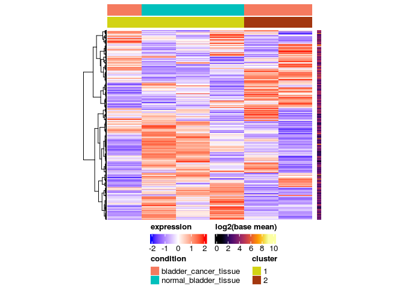

```r
ht <- Heatmap(mat_scaled, name = "expression",
        # km = 2,
        # column_km = 2,
        column_order = names(fit_cluster_kmeans$cluster[order(fit_cluster_kmeans$cluster)]),
        col = colorRamp2(c(-2, 0, 2), c("blue", "white", "red")),
        top_annotation = ha,
        # top_annotation_height = unit(4, "mm"),
        clustering_distance_columns = "euclidean",
        clustering_method_column = "complete",
        cluster_columns = F,
        clustering_distance_rows = "spearman",#"minkowski",
        clustering_method_rows = "ward.D2",
        cluster_rows = T,
        # row_dend_side = "right",
        # row_names_side = "left",
        show_row_names = T,
        show_column_names = F,
        width = unit(9, "cm"),
        show_row_dend = T,
        show_column_dend = T,
        # row_dend_reorder = TRUE,
        row_names_gp = gpar(fontsize = 5),
        heatmap_legend_param = list(direction = "horizontal")) +
Heatmap(base_mean, name = "log2(base mean)", show_row_names = F, width = unit(2, "mm"), col = inferno(255), show_column_names = F, row_names_gp = gpar(fontsize = 5), heatmap_legend_param = list(direction = "horizontal"))


draw(ht, heatmap_legend_side = "bottom", annotation_legend_side = "bottom")
```

## Gene expression analysis with *circIMPACTs*

### DEGs

Because of these analysis is highly time consuming for this tutorial have been reported the DEGs for only the circHIPK3.

```r
## filter out genes low expressed
min.count <- 20
min.col <- 5

filt.mat <- count.matrix[rowSums(count.matrix >= min.count) >= min.col, ]
```

```r
#normalized circRNAs data
circNormDeseq <- counts(dds.filt.expr, normalized = T) %>% as.data.frame()
circNormDeseq$circ_id <- rownames(circNormDeseq)

# library(doParallel)
# no_cores <- detectCores() - 5
# registerDoParallel(cores=no_cores)
# gene_mark <- foreach::foreach(i=1:25, .combine = rbind) %dopar% {
#
#   results.temp <- data.frame(gene.expression(circ_idofinterest = top25[i], circRNAs = circNormDeseq,
#                                        linearRNAs = filt.mat,
#                                        colData = coldata.df, padj = 0.05,
#                                        group = circIMPACT$group.df[circIMPACT$group.df$circ_id%in%top25[i],],
#                                        covariates = NULL), circIMPACT = top25[i])
# }

gene_mark_hipk3 <- data.frame(gene.expression(circ_idofinterest = "11:33286412-33287511",
                                             circRNAs = circNormDeseq,
                                             linearRNAs = filt.mat,
                                             colData = coldata.df,
                                             padj = 0.1,
                                             group = circIMPACT$group.df[circIMPACT$group.df$circ_id%in%"11:33286412-33287511",],
                                             covariates = NULL),
                              circIMPACT = "11:33286412-33287511")
```

```r
gene_mark_hip <- as.data.table(gene_mark_hipk3)
gene_mark_tab = gene_mark_hip %>% dplyr::group_by(circIMPACT, n.degs) %>% dplyr::mutate(UP=sum(log2FoldChange>0), DW=sum(log2FoldChange<0)) %>% dplyr::select(circIMPACT, n.degs, UP, DW)

gene_mark_hip %>% dplyr::rename("Gene" = "gene_id", "logFC" = "log2FoldChange") %>%
  arrange(padj) %>%
  select(circIMPACT, Gene, logFC) %>% head(20) %>%
  formattable::formattable(., align = c("c","c","c"), list(
          gene_id = formattable::formatter("span", style = ~ formattable::style(color = "grey", font.weight = "bold")),
          circIMPACT = formattable::formatter("span", style = ~ formattable::style(color = "grey", font.weight = "bold")),
          logFC = circIMPACT::color_tile3(digits = 3, n = 18, fun = "comma", palette = "PiYG")))
```

| circIMPACT | Gene | logFC |
| --- | --- | --- |
| 11:33286412-33287511 | FHL1 | 5.770 |
| 11:33286412-33287511 | NFASC | 3.992 |
| 11:33286412-33287511 | NTRK2 | 4.288 |
| 11:33286412-33287511 | PDE7B | 5.679 |
| 11:33286412-33287511 | PGM5 | 6.356 |
| 11:33286412-33287511 | ITIH5 | 4.937 |
| 11:33286412-33287511 | NCAM1 | 3.840 |
| 11:33286412-33287511 | EYA1 | 4.655 |
| 11:33286412-33287511 | PREX2 | 3.972 |
| 11:33286412-33287511 | HPSE2 | 4.211 |
| 11:33286412-33287511 | ZNF208 | 4.652 |
| 11:33286412-33287511 | MEG8 | 3.308 |
| 11:33286412-33287511 | ADAM33 | 3.374 |
| 11:33286412-33287511 | COL21A1 | 5.406 |
| 11:33286412-33287511 | SENP6 | 3.599 |
| 11:33286412-33287511 | AMY2B | 4.361 |
| 11:33286412-33287511 | SPATA6 | 3.033 |
| 11:33286412-33287511 | ADAMTSL3 | 3.757 |
| 11:33286412-33287511 | CFD | 4.544 |
| 11:33286412-33287511 | LMOD1 | 4.651 |

```r
# knitr::kable(gene_mark %>% dplyr::group_by(circRNA_markers, n.degs) %>%
# dplyr::summarise(DEGs = paste(sort(gene_id),collapse=", ")),
#       escape = F, align = "c", row.names = T, caption = "circRNA-DEGs assosiation") %>% kable_styling(c("striped"), full_width = T)
gene_mark_hip[gene_mark_hip$gene_id=="HPSE",]
```

```
#>    gene_id baseMean log2FoldChange     lfcSE      stat     pvalue       padj
#> 1:    HPSE 437.0168      -1.894013 0.7530104 -2.515255 0.01189462 0.06367762
#>    n.degs           circIMPACT
#> 1:   3232 11:33286412-33287511
```

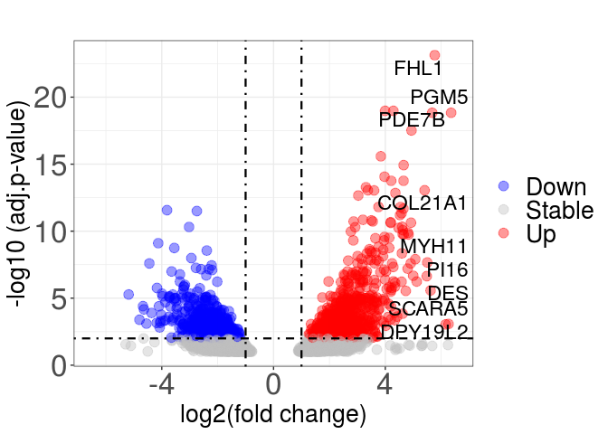

```r
# head(gene_mark_hip)
# Make a basic volcano plot
gene_mark_hipk3$expression = ifelse(gene_mark_hipk3$padj <= 0.01 & abs(gene_mark_hipk3$log2FoldChange) >= 1,
                     ifelse(gene_mark_hipk3$log2FoldChange >= 1 ,'Up','Down'),
                     'Stable')
p <- ggplot(data = gene_mark_hipk3,
            aes(x = log2FoldChange,
                y = -log10(padj),
                colour=expression,
                label = gene_id)) +
  geom_point(alpha=0.4, size=3.5) +
  geom_text_repel(aes(label=ifelse((abs(log2FoldChange) >= 5)&(padj<=0.01), gene_id, "")), color = "black", size = 6) +
  scale_color_manual("",
                     guide = guide_legend(title.position = "top",
                                          ncol = 1,
                                          title.hjust = .5),
                     values = setNames(c("blue", "grey","red"),
                                       nm = c("Down", "Stable","Up"))) +
  # scale_color_manual(values=c("blue", "grey","red"))+
  xlim(c(-6.5, 6.5)) +
  geom_vline(xintercept=c(-1,1),lty=4,col="black",lwd=0.8) +
  geom_hline(yintercept = 2,lty=4,col="black",lwd=0.8) +
  labs(x="log2(fold change)",
       y="-log10 (adj.p-value)",
       title="")  +
  theme_bw()+
  theme(plot.title = element_text(hjust = 0.5),
        legend.position="right",
        legend.title = element_blank(),
        legend.text = element_text(size=20),
        text = element_text(size=20),
        axis.text.x = element_text(size=25),
        axis.text.y = element_text(size=25))

p
```

```r
#ggplotly(p)
```

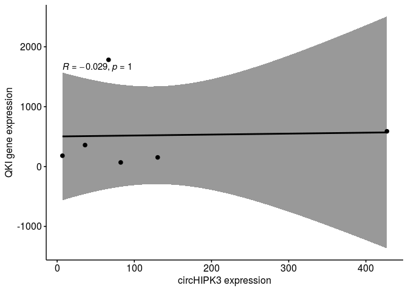

```r
my_data = data.frame(circHIPK3 = as.vector(t(circNormDeseq["11:33286412-33287511",-7])),
                     HPSE = filt.mat["HPSE",])
ggscatter(my_data, x = "circHIPK3", y = "HPSE",
          add = "reg.line", conf.int = TRUE,
          cor.coef = TRUE, cor.method = "spearman",
          xlab = "circHIPK3 expression", ylab = "QKI gene expression")
```

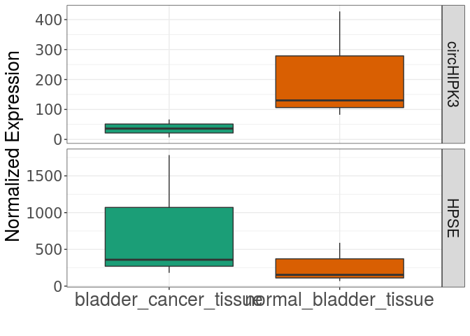

```r
my_data = data.frame(circHIPK3 = as.vector(t(circNormDeseq["11:33286412-33287511",-7])),
                     HPSE = filt.mat["HPSE",])
my_data$sample_id = rownames(my_data)
my_data$condition = meta$condition[match(my_data$sample_id, meta$sample)]
ggplot(reshape2::melt(my_data, id.var = c("sample_id","condition")),
       aes(x=condition, y=value, group=condition)) +
  geom_boxplot(aes(fill=condition)) +
  facet_grid( variable ~ ., scales='free') +
  scale_fill_manual(values = c("#1B9E77","#D95F02")) +
theme_bw() +
  xlab("") +
  ylab("Normalized Expression") +
  theme(plot.title = element_text(hjust = 0.5),
        legend.position="none",
        legend.title = element_blank(),
        legend.text = element_text(size=20),
        text = element_text(size=20),
        axis.text.x = element_text(size=20),
        axis.text.y = element_text(20),
        strip.text.x = element_text(size = 20))
```

### Classification

```r
library(doParallel)
library(caret)
library(dplyr)
library(tidyr)
library(data.table)
# no_cores <- detectCores() - 6
# registerDoParallel(cores=no_cores)
# gene.class <- foreach::foreach(i=1:25, .combine = list) %dopar% {
#
#   results.temp <- gene_class(circ_idofinterest = top25[i], circRNAs = circNormDeseq,
#                                        linearRNAs = filt.mat, colData = coldata.df,
#                                        group = circIMPACT$group.df[circIMPACT$group.df$circ_id%in%top25[i],],
#                                        covariates = NULL, th.corr = 0.3)
# }

gene_class_hipk3 <- circIMPACT::gene.class(circ_idofinterest = "11:33286412-33287511",
                                           circRNAs = circNormDeseq,
                                       linearRNAs = filt.mat,
                                       colData = coldata.df,
                                       group =
              circIMPACT$group.df[circIMPACT$group.df$circ_id%in%"11:33286412-33287511",],
                                       covariates = NULL,
              th.corr = 0.3)
```

[output not shown]

```r
#p
#ggplotly(p)
```

```r
VI <- importance(gene_class_hipk3$RF)
VI.mat <- as.data.frame(VI)
r <- rownames(VI)
VI.mat$gene <- r
VI.mat <- VI.mat[order(VI.mat$MeanDecreaseAccuracy, decreasing = T),]
VI.mat <- as.data.table(VI.mat)


# VI.mat
VI.mat %>% mutate_at(1:4, round, 3) %>% head() %>%
  mutate_if(is.numeric, function(x) {
    cell_spec(x, bold = T,
              color = spec_color(x, end = 0.9),
              font_size = spec_font_size(x))
  }) %>%
  kable(escape = F, align = "c", row.names = F, caption = "Table of selected genes used for classification of subgroups defined by circRNAs variation. For each class of response variable there is a OOB error rate of classification. In the 4th column there is the importance of the variable in the growing of the the random forest") %>%
  kable_styling(c("striped"), full_width = F)
```

Table of selected genes used for classification of subgroups defined by circRNAs variation. For each class of response variable there is a OOB error rate of classification. In the 4th column there is the importance of the variable in the growing of the the random forest

| high | low | MeanDecreaseAccuracy | MeanDecreaseGini | gene |
| --- | --- | --- | --- | --- |
| 2.609 | 2.655 | 2.635 | 0.036 | FHL1 |
| 2.609 | 2.609 | 2.619 | 0.048 | SCARA5 |
| 2.407 | 2.407 | 2.419 | 0.031 | ITGA8 |
| 2.407 | 2.364 | 2.409 | 0.039 | DMD |
| 2.126 | 2.242 | 2.205 | 0.066 | DHCR24 |
| 2.115 | 2.188 | 2.205 | 0.021 | ROR1 |

## Enrichment analysis of DEGs

```r
library(enrichplot)

library(DOSE)

library(clusterProfiler)

organism = "org.Hs.eg.db"
library(organism, character.only = TRUE)
```

### GO

#### dot plot

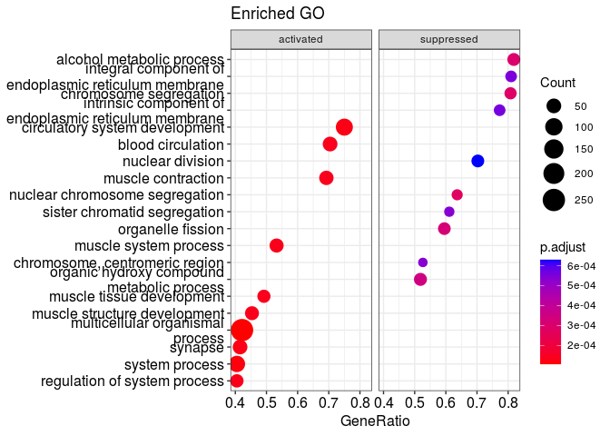

```r
enrichplot::dotplot(gse, showCategory=10, split=".sign", title = "Enriched GO") + facet_grid(.~.sign)
```

#### UPset plot

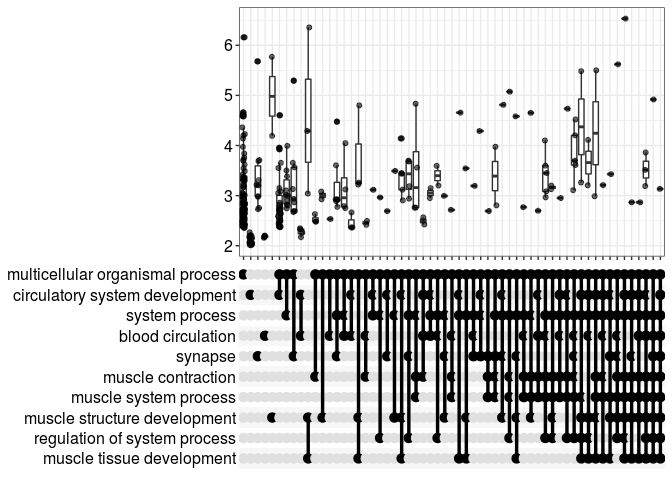

```r
upsetplot(gse, showCategory=10)
```

#### Table results

```r
kable(head(df_gse[like(core_enrichment,"HPSE/"),]), escape = F, align = "c", row.names = F, caption = "Enrichment of GO including HPSE gene") %>%
  kable_styling(c("striped"), full_width = F)
```

Enrichment of GO including HPSE gene

| ONTOLOGY | ID | Description | setSize | enrichmentScore | NES | pvalue | p.adjust | qvalues | rank | leading_edge | core_enrichment |
| --- | --- | --- | --- | --- | --- | --- | --- | --- | --- | --- | --- |

### KEGG

#### dot plot of DEGs

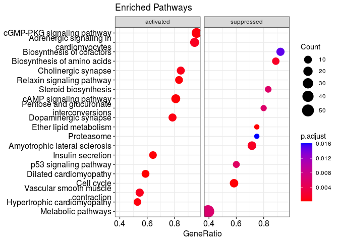

```r
dotplot(kk2, showCategory=10, split=".sign", title = "Enriched Pathways") + facet_grid(.~.sign)
```

#### UPset plot of DEGs

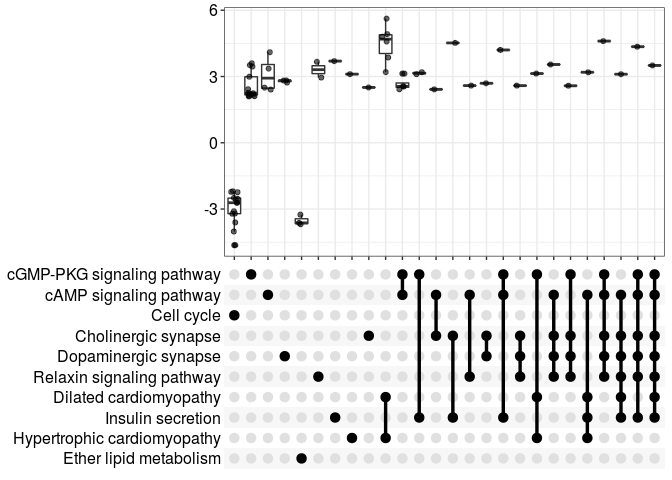

```r
upsetplot(kk2, showCategory = 10)
```

## Enrichment analysis of Classification results

```r
library(enrichplot)

library(DOSE)

library(clusterProfiler)

organism = "org.Hs.eg.db"
library(organism, character.only = TRUE)
```

### GO

```r
#subset gene symbol deregulated using the interesting circRNA marker as stratificator
# geneList <- gene_mark$log2FoldChange[gene_mark$circIMPACT==markers.circrnas[5]]
geneList <- gene_mark_hipk3$log2FoldChange[gene_mark_hipk3$gene_id%in%rownames(gene_class_hipk3$VI)]
names(geneList) <- gene_mark_hipk3$gene_id[gene_mark_hipk3$gene_id%in%rownames(gene_class_hipk3$VI)]

# order gene list by foldchange
geneList = sort(geneList, decreasing = TRUE)
# names(geneList) <- gene_mark$Gene[gene_mark$circIMPACT==markers.circrnas[5]]


gse <- gseGO(geneList=geneList,
             ont ="ALL",
             keyType = "SYMBOL",
             nPerm = 10000,
             minGSSize = 3,
             maxGSSize = 800,
             pvalueCutoff = 0.05,
             verbose = TRUE,
             OrgDb = organism,
             pAdjustMethod = "none")

df_gse <- gse@result
df_gse = as.data.table(df_gse)
```

#### dot plot of DEGs

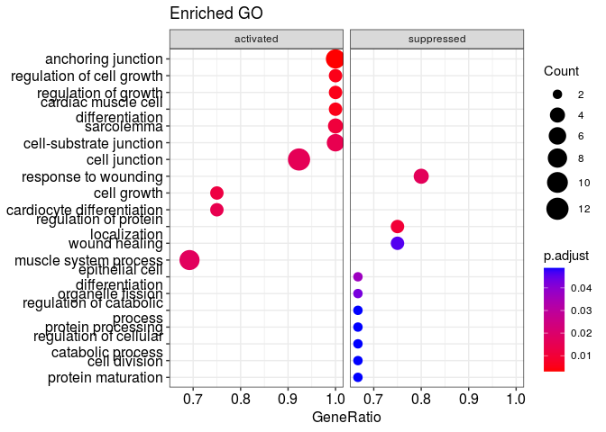

```r
enrichplot::dotplot(gse, showCategory=10, split=".sign", title = "Enriched GO") + facet_grid(.~.sign)
```

#### UPset plot of DEGs

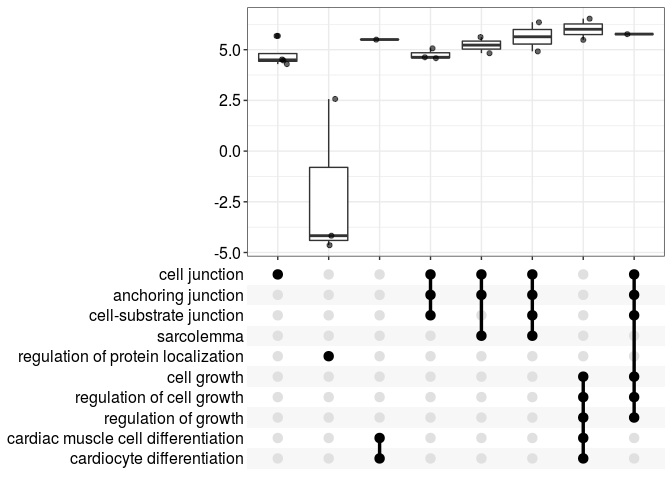

```r
upsetplot(gse, showCategory=10)
```

#### Table results

```r
kable(head(df_gse), escape = F, align = "c", row.names = F, caption = "Enrichment of GO including HPSE gene") %>%
  kable_styling(c("striped"), full_width = F)
```

| ONTOLOGY | ID | Description | setSize | enrichmentScore | NES | pvalue | p.adjust | qvalues | rank | leading_edge | core_enrichment |
| --- | --- | --- | --- | --- | --- | --- | --- | --- | --- | --- | --- |
| CC | GO:0070161 | anchoring junction | 8 | 0.6567164 | 2.008506 | 0.0030454 | 0.0030454 | 0.9257932 | 31 | tags=100%, list=41%, signal=66% | PGM5/FHL1/DES/CNN1/DMD/SYNM/SYNPO2/ITGA8 |
| BP | GO:0001558 | regulation of cell growth | 3 | 0.8750000 | 1.839398 | 0.0051993 | 0.0051993 | 0.9257932 | 12 | tags=100%, list=16%, signal=88% | MYOCD/FHL1/PI16 |
| BP | GO:0040008 | regulation of growth | 3 | 0.8750000 | 1.839398 | 0.0051993 | 0.0051993 | 0.9257932 | 12 | tags=100%, list=16%, signal=88% | MYOCD/FHL1/PI16 |
| BP | GO:0055007 | cardiac muscle cell differentiation | 3 | 0.8750000 | 1.839398 | 0.0051993 | 0.0051993 | 0.9257932 | 12 | tags=100%, list=16%, signal=88% | MYOCD/MYH11/PI16 |
| BP | GO:0032880 | regulation of protein localization | 4 | -0.7605634 | -1.882084 | 0.0097752 | 0.0097752 | 0.9257932 | 22 | tags=100%, list=29%, signal=75% | EDNRA/KRT20/CCNE1 |
| CC | GO:0042383 | sarcolemma | 4 | 0.7605634 | 1.798796 | 0.0107726 | 0.0107726 | 0.9257932 | 21 | tags=100%, list=28%, signal=76% | PGM5/DES/DMD/SYNM |

### KEGG

#### dot plot

```r
dotplot(kk2, showCategory=10, split=".sign", title = "Enriched Pathways") + facet_grid(.~.sign)
```

[output not shown]

#### UPset plot

```r
upsetplot(kk2, showCategory = 10)
```

[output not shown]